# Chapter 2

# Discrete Random Variables

Given an experiment: rolling a 6 face die. We can get any of the following outcomes [1,2,3,4,5,6]. The set of all possible outcomes is called **Sample space**. Sample of the above experiment is [1,2,3,4,5,6]. **Random Variable** associates a value to the outcome of the experiment. **A random variable is a real-valued function of the outcome of the experiment.**

Given above experiment we can have following random variables:

1. iseven(x) in {1,0} value of random variable is 1 if face f is [2,4,6] else 0 [1,3,5] . i.e. $iseven(x) \in \{1,0\}$
2. value(x) in {1,2,3,4,5,6} same as the outcome of die roll . i.e. $value(x) \in \{1,2,3,4,5,6\}$
3. ...

## Probability Mass Fuction (PMF)

$PMF$ of $X$ is denoted as $p_X$. Function $p_X(x)$ is probability of event $\{X=x\}$ i.e. random variable $X$ is equal to $x$, where $x$ is one of the possible values $X$

Let the experiment consist of two independent tosses of a fair coin, and let $X$ be the number of heads obtained. Then the $PMF$ of $X$ is

$p_X(x) = \left\{ \begin{array}{ll} {1 \over 4} & \mbox{if } x = 0 \mbox{ or } x = 2 \\ {1 \over 2} & \mbox{if } x = 1 \\ {0} & \mbox{otherwise} \end{array} \right.$

Calculation of the PMF of a Random Variable X For each possible value x of X:

1. Collect all the possible outcomes that give rise to the event {X = x}.
2. Add their probabilities to obtain pX(x).

### Bernoulli Random Variable

Consider the toss of a biased coin, which comes up a head with probability p, and a tail with probability 1 − p. The Bernoulli random variable takes the two values 1 and 0, depending on whether the outcome is a head or a tail:

$X= \left\{ \begin{array}{ll} {1} & \mbox{ if head}\\ {0} & \mbox{ if tail} \end{array} \right.$

Its $PMF$ is :

$p_X(x)= \left\{ \begin{array}{ll} {p} & \mbox{ if } x = 1\\ {1-p} & \mbox{ if } x = 0 \end{array} \right.$

```python
"""Below we will we will write code of Bernoulli Random Variable.
class BernoulliSample simulates probability of outcomes when coin
is tossed large number of times
"""
import numpy as np
from collections import Counter
from matplotlib import pyplot as plt

class BernouliSample:
  def __init__(self,p,samples=1000000):
    randamMax = 100

    data = np.random.choice(randamMax,samples)
    mask =(data <randamMax*p)
    data = np.zeros(samples,dtype=np.int)
    data[mask]=1
    self.data = data
    self.counter = Counter(self.data)

    self.prob = {} #works as PMF function
    for x,y in self.counter.items():
      self.prob[x] = y/float(samples)

  def PMF(self,x):
    return self.prob.get(x,0)
```

```python
b = BernouliSample(0.3)
b.PMF(0)
```

```
0.698741
```

```python
b.PMF(1)
```

```
0.301259
```

```python
#check PMF property of sum = 1
sum(b.prob.values())
```

```
1.0
```

```python
"""Below we will we will write code of Bernoulli Random Variable.
class Bernoulli is based on mathematical formula
"""
import numpy as np
from collections import Counter
import seaborn as sns
from matplotlib import pyplot as plt

class Bernouli:
  def __init__(self,p):
    self.prob = {}
    self.prob[1] = p
    self.prob[0] = 1-p

  def PMF(self,x):
    return self.prob.get(x,0)

b = Bernouli(0.4)
b.PMF(1)
```

```
0.4
```

```python
b.PMF(0)
```

```
0.6
```

```python
#check PMF property of sum = 1
sum(b.prob.values())
```

```
1.0
```

### The Binomial Random Variable

A biased coin is tossed n times. At each toss, the coin comes up a head with probability $p$, and a tail with probability $1−p$, independently of prior tosses. Let X be the number of heads in the n-toss sequence. We refer to X as a **binomial random variable** with parameters $n$ and $p$. The $PMF$ of $X$:

$p_X(k) = P(X=k) = {n \choose k}p^k(1-p)^{n-k} , k =0,1,2....,n.$

```python
"""Below we will we will write code of Binomial Random Variable.
class Bernoulli is based on mathematical formula above
"""
import numpy as np
from collections import Counter
from matplotlib import pyplot as plt
import operator as op

class Binomial:
  def __init__(self,p,n):
    self.prob = {}
    self.p = p
    self.n = n
    self.p_pow_table = np.zeros(n+1)
    self.p_1_pow_table = np.zeros(n+1)

    p_pow = 1.0
    for k in range(n+1):
      self.p_pow_table[k]=p_pow
      p_pow *=p

    p_1_pow = 1.0
    p_1 = 1.0-p
    for k in range(n+1):
      self.p_1_pow_table[k]=p_1_pow
      p_1_pow *=p_1

    for k in range(n+1):
        self.prob[k] = self.pmfFunc(k)

  def ncr(self,n, r):
    r = min(r, n-r)
    if r == 0: return 1
    numer = reduce(op.mul, xrange(n, n-r, -1))
    denom = reduce(op.mul, xrange(1, r+1))
    return numer//denom

  def pmfFunc(self,k):
    n = self.n
    returnVal = self.ncr(n,k)*self.p_pow_table[k]*self.p_1_pow_table[n-k]
    return returnVal


  def PMF(self,x):
    return self.prob.get(x,0)

b = Binomial(p=0.5,n=9)
sum(b.prob.values())
```

```
1.0
```

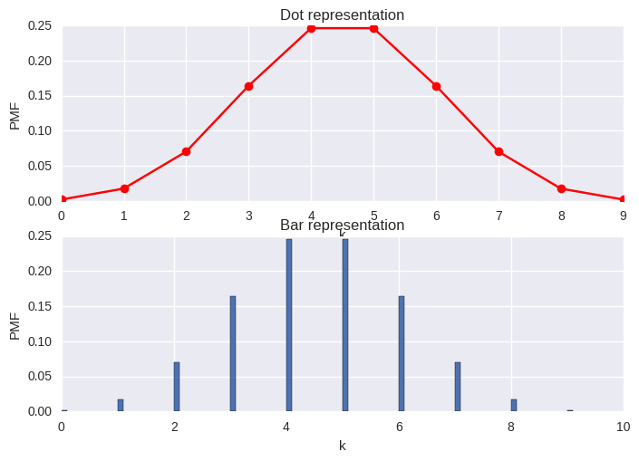

```python
plt.subplot(2, 1, 1)
plt.plot(b.prob.keys(), b.prob.values(),'ro-')
plt.title('Dot representation')
plt.xlabel('k')
plt.ylabel('PMF')

plt.subplot(2, 1, 2)
plt.bar(b.prob.keys(), b.prob.values(),0.1)
plt.title('Bar representation')
plt.xlabel('k')
plt.ylabel('PMF')

plt.show()
```

```python
"""Below we will we will write code of Binomial Random Variable.
class BinomialSample simulates probability of outcomes
when event of n coin toss is done large number of times
It uses BernoulliSample
"""
class BinomialSample:
  def __init__(self,p,n,samples=100000):
    self.data = np.zeros(samples,dtype=np.int)

    for i in range(n):
      #if i%20==0:
      #  print i
      tempB = BernouliSample(p,samples=samples)
      self.data += tempB.data

    self.counter = Counter(self.data)
    self.prob = {}

    for x in range(n+1):
      y = self.counter.get(x,0)
      self.prob[x] = y/float(samples)

  def PMF(self,x):
    return self.prob.get(x,0)

bS = BinomialSample(p=0.5,n=9)
```

```python
sum(bS.prob.values())
```

```
1.0000000000000002
```

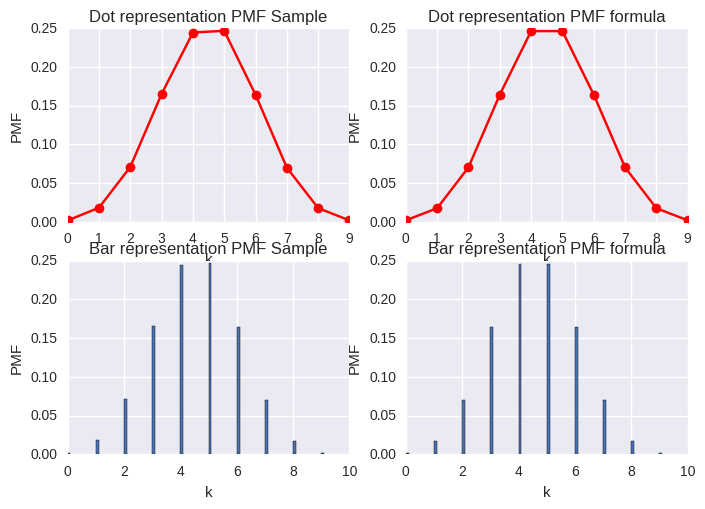

```python
plt.subplot(2, 2, 1)
plt.plot(bS.prob.keys(), bS.prob.values(),'ro-')
plt.title('Dot representation PMF Sample')
plt.xlabel('k')
plt.ylabel('PMF')

plt.subplot(2, 2, 3)
plt.bar(bS.prob.keys(), bS.prob.values(),0.1)
plt.title('Bar representation PMF Sample')
plt.xlabel('k')
plt.ylabel('PMF')

plt.subplot(2, 2, 2)
plt.plot(b.prob.keys(), b.prob.values(),'ro-')
plt.title('Dot representation PMF formula')
plt.xlabel('k')
plt.ylabel('PMF')

plt.subplot(2, 2, 4)
plt.bar(b.prob.keys(), b.prob.values(),0.1)
plt.title('Bar representation PMF formula')
plt.xlabel('k')
plt.ylabel('PMF')

plt.show()
```

As you can see from above figures both generating PMF by large number samples or by mathematical formula are similar

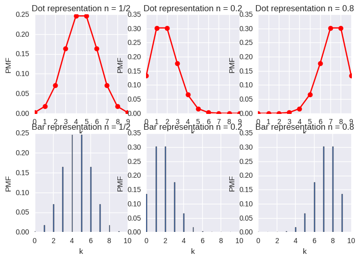

```python
b_08 = Binomial(p=0.8,n=9)
b_02 = Binomial(p=0.2,n=9)

plt.subplot(2, 3, 1)
plt.plot(b.prob.keys(), b.prob.values(),'ro-')
plt.title('Dot representation n = 1/2')
plt.xlabel('k')
plt.ylabel('PMF')

plt.subplot(2, 3, 2)
plt.plot(b_02.prob.keys(), b_02.prob.values(),'ro-')
plt.title('Dot representation n = 0.2')
plt.xlabel('k')
plt.ylabel('PMF')

plt.subplot(2, 3, 3)
plt.plot(b_08.prob.keys(), b_08.prob.values(),'ro-')
plt.title('Dot representation n = 0.8')
plt.xlabel('k')
plt.ylabel('PMF')

plt.subplot(2, 3, 4)
plt.bar(b.prob.keys(), b.prob.values(),0.1)
plt.title('Bar representation n = 1/2')
plt.xlabel('k')
plt.ylabel('PMF')

plt.subplot(2, 3, 5)
plt.bar(b_02.prob.keys(), b_02.prob.values(),0.1)
plt.title('Bar representation n = 0.2')
plt.xlabel('k')
plt.ylabel('PMF')

plt.subplot(2, 3, 6)
plt.bar(b_08.prob.keys(), b_08.prob.values(),0.1)
plt.title('Bar representation n = 0.8')
plt.xlabel('k')
plt.ylabel('PMF')
plt.show()
```

The PMF of a binomial random variable. If p = 1/2, the PMF is symmetric around n/2. Otherwise, the PMF is skewed towards 0 if p < 1/2, and towards n if p > 1/2.

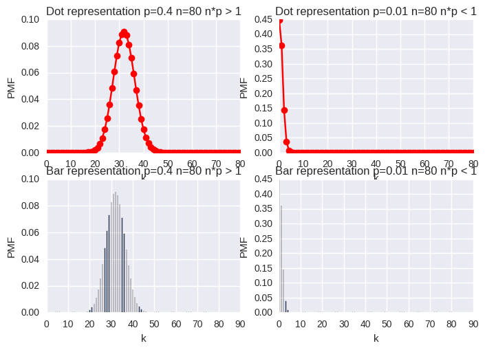

```python
b_08 = Binomial(p=0.01,n=80)

b_02 = Binomial(p=0.4,n=80)


plt.subplot(2, 2, 1)
plt.plot(b_02.prob.keys(), b_02.prob.values(),'ro-')
plt.title('Dot representation p=0.4 n=80 n*p > 1')
plt.xlabel('k')
plt.ylabel('PMF')

plt.subplot(2, 2, 2)
plt.plot(b_08.prob.keys(), b_08.prob.values(),'ro-')
plt.title('Dot representation p=0.01 n=80 n*p < 1')
plt.xlabel('k')
plt.ylabel('PMF')

plt.subplot(2, 2, 3)
plt.bar(b_02.prob.keys(), b_02.prob.values(),0.1)
plt.title('Bar representation p=0.4 n=80 n*p > 1')
plt.xlabel('k')
plt.ylabel('PMF')

plt.subplot(2, 2, 4)
plt.bar(b_08.prob.keys(), b_08.prob.values(),0.1)
plt.title('Bar representation p=0.01 n=80 n*p < 1')
plt.xlabel('k')
plt.ylabel('PMF')
plt.show()
```

Notice the above figure when n*p < 1 and n*p > 1. This can help us understand how Binomial Random Variable is related to Poison random variable n later section

### The Geometric Random Variable

Suppose that we repeatedly and independently toss a biased coin with probability of a head $p$, where $0 < p < 1$. The geometric random variable is the number $X$ of tosses needed for a head to come up for the first time. Its $PMF$ is given by:

$p_X(k) = (1-p)^{k-1}p$, where $k = 1,2,...,$

```python
"""Below we will we will write code of Geometric Random Variable.
class Geometric is based on mathematical formula above
"""

class Geometric:
    def __init__(self,p,n=20):
        self.prob = {}
        curProb = p
        p_1 = 1.0 - p
        for k in range(n):
            self.prob[k+1] = curProb
            curProb *= p_1

    def PMF(self,x):
        return self.prob.get(x,0)
```

```python
g = Geometric(p=0.1,n=60)
# checking sum of PMF is 1
print sum(b.prob.values())
```

```
1.0
```

```python
class GeometricSample:
  def __init__(self,p,n,samples=1000000):
    self.data = np.zeros(samples,dtype=np.int)
    for i in range(n):
      if i%20==0:
        print i
      tempB = BernouliSample(p,samples=samples)
      tempMask = (tempB.data==1)
      self.data[tempMask] = n-i
    self.counter = Counter(self.data)


    self.prob = {}
    #Remove 0's count
    self.counter.pop(0, None)
    totalCount = sum(self.counter.values())
    for x in range(n-1):
      y = self.counter.get(x+1,0)
      self.prob[x+1] = y/float(totalCount)

  def PMF(self,x):
        return self.prob.get(x,0)
```

```python
gs = GeometricSample(p=0.1,n=60)
# checking sum of PMF is 1
print sum(b.prob.values())
```

```
0
20
40
1.0
```

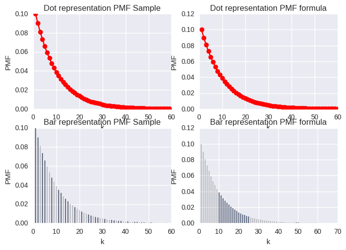

```python
plt.subplot(2, 2, 1)
plt.plot(gs.prob.keys(), gs.prob.values(),'ro-')
plt.title('Dot representation PMF Sample')
plt.xlabel('k')
plt.ylabel('PMF')

plt.subplot(2, 2, 3)
plt.bar(gs.prob.keys(), gs.prob.values(),0.1)
plt.title('Bar representation PMF Sample')
plt.xlabel('k')
plt.ylabel('PMF')

plt.subplot(2, 2, 2)
plt.plot(g.prob.keys(), g.prob.values(),'ro-')
plt.title('Dot representation PMF formula')
plt.xlabel('k')
plt.ylabel('PMF')

plt.subplot(2, 2, 4)
plt.bar(g.prob.keys(), g.prob.values(),0.1)
plt.title('Bar representation PMF formula')
plt.xlabel('k')
plt.ylabel('PMF')

plt.show()
```

As you can see from above figures both generating PMF by large number samples or by mathematical formula are similar

### Poisson Random Variable

A Poisson random variable takes nonnegative integer values. Its PMF is given by

$p_X(k) = e^{-\lambda}{\lambda^k \over k!}$, $k = 0, 1, 2, . . . ,$

the Poisson $PMF$ with parameter $\lambda$ is a good approximation for a binomial $PMF$ with parameters $n$ and $p$, provided $\lambda = np$, $n$ is very large, and $p$ is very small

```python
"""Below we will we will write code of Poisson Random Variable.
class Poisson is based on mathematical formula above
"""

class Poisson:
    def __init__(self,p,n=20):
        self.prob = {}
        self.l = float(n*p)
        self.e_l = pow(2.71828,self.l*(-1.0))
        self.l_k = np.zeros(n+1)

        curProb = self.e_l
        for k in range(n+1):
            self.prob[k] = curProb
            curProb *= (self.l/(k+1))


    def PMF(self,x):
        return self.prob.get(x,0)
```

```python
p_08 = Poisson(p=0.01,n=80)
p_02 = Poisson(p=0.4,n=80)
sum(p_08.prob.values())
```

```
1.000000538122319
```

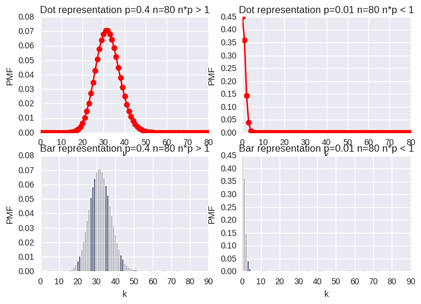

```python
plt.subplot(2, 2, 1)
plt.plot(p_02.prob.keys(), p_02.prob.values(),'ro-')
plt.title('Dot representation p=0.4 n=80 n*p > 1')
plt.xlabel('k')
plt.ylabel('PMF')

plt.subplot(2, 2, 2)
plt.plot(p_08.prob.keys(), p_08.prob.values(),'ro-')
plt.title('Dot representation p=0.01 n=80 n*p < 1')
plt.xlabel('k')
plt.ylabel('PMF')

plt.subplot(2, 2, 3)
plt.bar(p_02.prob.keys(), p_02.prob.values(),0.1)
plt.title('Bar representation p=0.4 n=80 n*p > 1')
plt.xlabel('k')
plt.ylabel('PMF')

plt.subplot(2, 2, 4)
plt.bar(p_08.prob.keys(), p_08.prob.values(),0.1)
plt.title('Bar representation p=0.01 n=80 n*p < 1')
plt.xlabel('k')
plt.ylabel('PMF')
plt.show()
```